# Repducible Research, week 2

Radsaur

24 12 2021

## Introduction

As per the assignment we have to create an RMarkdown document to analyze a number of steps performed by individuals. In order to work as effective as R permits we have to upload certain pacakges. The R code shows whcihc packages were uploaded:

```r
library(dplyr)
library(tidyverse)
```

```r
library(ggplot2)
library(xtable)
library(lubridate)
```

## 1. Code for reading in the dataset and/or processing the data

In order to read the dataset, we first set the working directroey and then command R to read the file.

```r
setwd('D:/DOCS/Sauran.S/R/Coursera/Literate_programming')
df<- read.csv('activity.csv')
summary(df)
```

```
##      steps                date          interval
##  Min.   :  0.00   2012-10-01:  288   Min.   :   0.0
##  1st Qu.:  0.00   2012-10-02:  288   1st Qu.: 588.8
##  Median :  0.00   2012-10-03:  288   Median :1177.5
##  Mean   : 37.38   2012-10-04:  288   Mean   :1177.5
##  3rd Qu.: 12.00   2012-10-05:  288   3rd Qu.:1766.2
##  Max.   :806.00   2012-10-06:  288   Max.   :2355.0
##  NA's   :2304     (Other)   :15840
```

## 2. Histogram of the total number of steps taken each day

Below we present the histogram of the total numbe of steps. In order to plot the histogram, some data preprocessing has to be done first. Since the tasks requests that we plot the total number of steps, we have to sum up the number of steps per each day. In the code below, the first line calculates the number of steps per day and the second one plots the histogram.

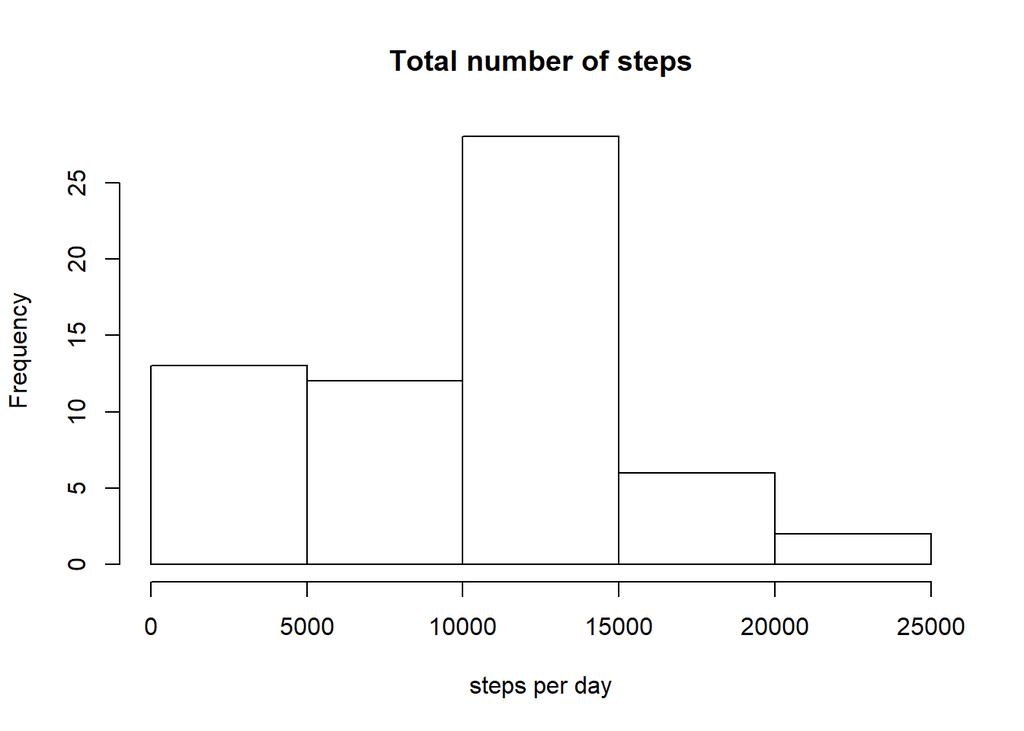

```r
tot_steps<-df %>% group_by(date) %>% summarize(steps=sum(steps,na.rm = T))

tot_steps$steps %>% hist(main='Total number of steps',xlab='steps per day' ,ylim=c(0,28))
```

The code below shows how we calculated the mean and median number of steps per day

```r
mean_number<-tot_steps$steps %>% mean(na.rm=T) %>% round(2)
median_number<-tot_steps$steps %>% median(na.rm=T)%>% round(2)
```

## 4. Time series plot of the average number of steps taken

Following the instructions we do a time series plot of the 5-minute interval (x-axis) and the average number of steps taken, averaged across all days (y-axis)

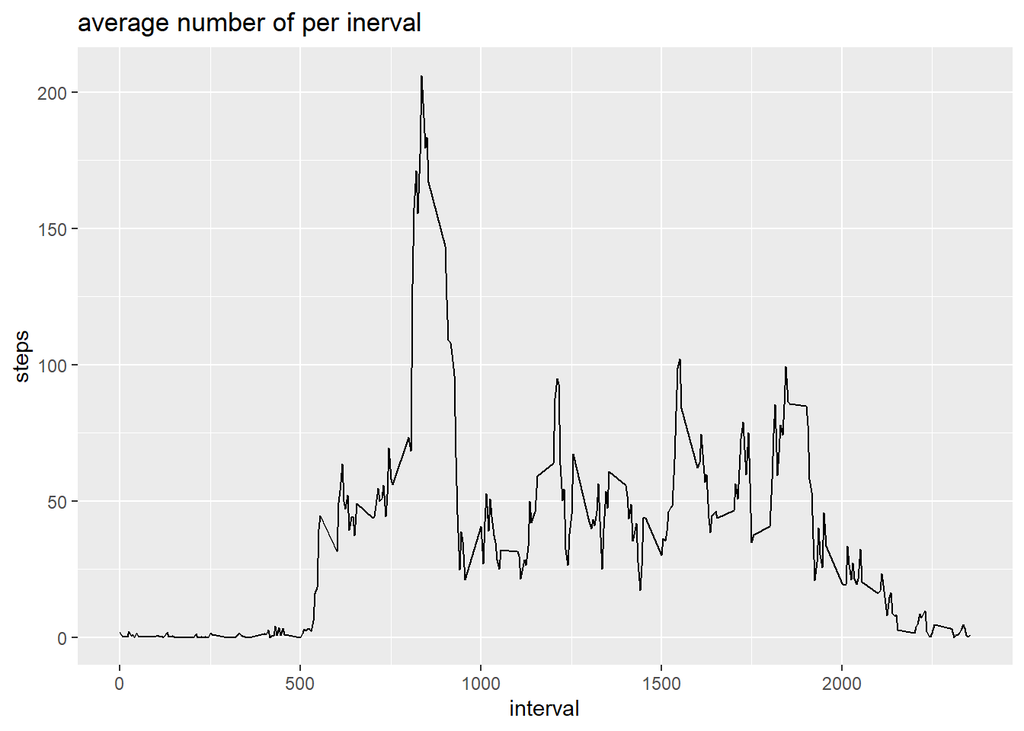

```r
df %>% group_by(interval) %>%
    summarize(steps=mean(steps,na.rm = T))->intervals

intervals %>% ggplot(aes(x=interval, y=steps)) +
    geom_line()+labs(title = 'average number of per inerval')
```

## 5. The 5-minute interval that, on average, contains the maximum number of steps

The interval with the maximum number of steps can be found as follows:

```r
max_interv<- intervals[intervals$steps==intervals$steps %>% max,1]
```

So, the max number of steps inteval is 835

## 6. Code to describe and show a strategy for imputing missing data

##### We have to calculate and report the total number of missing values in the dataset (i.e. the total number of rows with NAs)

First, we look at the composition of dataset using the function, ‘str’. It shows that the only row which contains the NAs is “steps”. So we calculate the number of missing values in “steps” as follows

```r
df %>% str
```

```
## 'data.frame':    17568 obs. of  3 variables:
##  $ steps   : int  NA NA NA NA NA NA NA NA NA NA ...
##  $ date    : Factor w/ 61 levels "2012-10-01","2012-10-02",..: 1 1 1 1 1 1 1 1 1 1 ...
##  $ interval: int  0 5 10 15 20 25 30 35 40 45 ...
```

```r
NA_numb<- is.na(df$steps) %>% sum()
```

So the number of missing values is 2304

##### The second taks is to devise a strategy for filling in all of the missing values in the dataset.

```r
library(mice)
```

Then we use the package to impute the missing values

```r
imputed_Data <- mice(df, maxit = 10, method = 'pmm', seed = 500,printFlag = F)
imputed_Data$imp$steps
completeData <- complete(imputed_Data,2)
```

[output not shown]

Let’s now check whether the function ‘str’ will show any NA’s

```r
completeData %>% str
```

```
## 'data.frame':    17568 obs. of  3 variables:
##  $ steps   : int  0 0 0 0 0 0 0 0 0 0 ...
##  $ date    : Factor w/ 61 levels "2012-10-01","2012-10-02",..: 1 1 1 1 1 1 1 1 1 1 ...
##  $ interval: int  0 5 10 15 20 25 30 35 40 45 ...
```

So, this time no NAs are not displayed.

## 7. Histogram of the total number of steps taken each day after missing values are imputed

Now, it is time to re-do the histogram and check whether it significantly differs from the histogram above which does contain missing values.

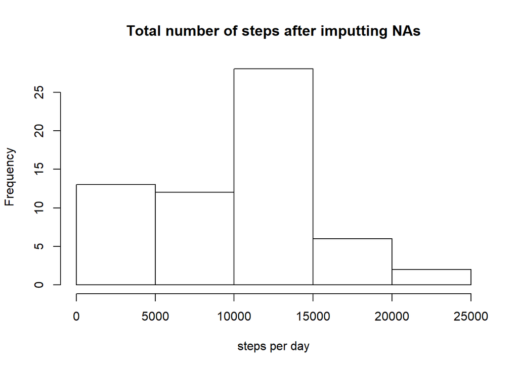

```r
group_steps<-completeData %>%group_by(date) %>% summarise(steps=sum(steps))
group_steps$steps %>% hist(main='Total number of steps after imputting NAs',xlab='steps per day')
```

The histogram looks quite similar to the histogram above.

```r
completeData$date<-completeData$date %>% ymd()
completeData$wday<-ifelse(completeData$date %>% wday()>5,'week_end','week_day')

completeData$wday %>% unique()
```

```
## [1] "week_day" "week_end"
```

Second, we calculate the mean of the steps calculated per interval across all days and plot the panel data.

```r
av_steps_weekdays<-completeData %>% group_by(interval,wday) %>% summarise(steps=mean(steps))
```

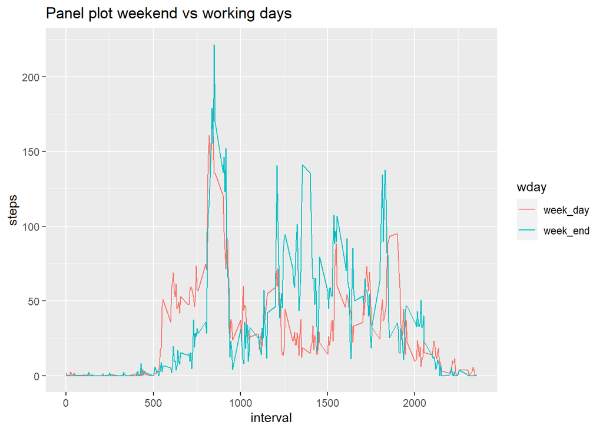

```r
ggplot(av_steps_weekdays, aes(interval, steps,color=wday))+geom_line()+
    labs(title = 'Panel plot weekend vs working days')
```